# CA3 - DAIE Project

Conor Crean & Daniel Lacey

2022-12-22

# **Data Analytics for Immersive Environments**

### *Descriptive and Inferential Analysis of a Jungian Sandplay VR Project*

##### *Abstract:*

- *Aim and Rationale*
- *Participants and Setting*
- *Experiment Design*
- *Results Gathering*
- *Major Findings*
- *Findings/Implications*

##### *Introduction:*

- *Topic and Context*
- *Rationale*
- *Hypothesis*

##### *Method:*

- *Participants*
- *Design*
- *Materials*
- *Procedure*

##### *Results:*

- *Descriptive Statistics*
- *Inferential Statistics*
- *Statistical Tests*
- *Magnitude and Direction of Results*

##### *Discussion:*

- *Outline findings and relation to the hypothesis*
- *Limitations*

# Abstract

### **Aim and Rationale**

The aim of this study is to test whether a virtual Jungian sandplay environment presented to psychotherapy patients undergoing treatment for PTSD has a positive effect on their CPSS (child PTSD symptom scale) scores compared to a control group that is subjected to CBT (Cognitive Behavioural Therapy) alone.

### **Participants and Setting**

The study consists of 150 patients, aged between 18-25, age was not recorded but gender was. recorded 75 are male, 75 Female. There is an even amount across the two gender groups listed in the data. A sample of people are undergoing treatment for PTSD.

### **Experiment Design**

The sample of 150 patients were divided into three groups. There was a Control group which involved traditional CBT treatment. The second group were the Static which involved a non-animated model content in VR. The third group was the Animated group which involved animated model content within VR.

### **Results Gathering**

The results were gathered from the three distinct groups over 12 weeks (about 3 months) during 50-minute treatment sessions. The PTSD results were measured using observer-rated and self-reported mechanisms. The measurements were taken at the start and end of the study

### **Major Findings**

### **Findings/Implications**

If this experiment shows a similar positive therapeutic effect to non-VR Jungian Sandplay then it opens the possibility of easy access to the Jungian Sandplay therapeutic method via VR instead of having to attend a physical location to receive the therapy. Thus, VR could possibly fill the role as a useful analogue to real life Jungian Sandplay making it a much more widely available therapeutic method to alleviate PTSD.

# Introduction

### **Topic and Context**

Does a virtual Jungian sandplay environment have a meaningful effect on CPSS scores in comparison to CBT.

### **Rationale**

### **Hypothesis**

# Method

### **Participants**

150 young adults were recruited for the study (M=75, F=75) using random sampling. They were divided into 3 groups:

- Control (traditional CBT with no VR)
- Static (non-animated model content with VR)
- Animated (animated model content with VR)

All the patients were young adults between 18 – 25 years old. Gender information was recorded. All groups were of equal size. Each group was evenly split by sex (M=25, F=25).

### **Design**

The 3 groups underwent 12 weeks (about 3 months) of treatment for 50 minutes per week with a therapist. During that time, the participants either underwent traditional CBT or used one of the 2 VR apps (Static non-animated model content, Animated model content). PTSD measurements for all groups were measured using the observer-rated and the CPSS self-report mechanisms. Measurements were taken pre-trial and post-trial for each group.

### **Materials**

### **Procedure**

# Results

##### *Cleaning data*

```
## ──────────────────────────────────────────────────────── Delimiter: "," chr
## (2): gender, test_group dbl (5): ...1, pre_trial_cpss, post_trial_cpss,
## pre_trial_or, post_trial_or
```

```
## # A tibble: 10 × 7
##     ...1 gender test_group pre_trial_cpss post_trial_cpss pre_trial_or post_tr…¹
##    <dbl> <chr>  <chr>               <dbl>           <dbl>        <dbl>     <dbl>
##  1     1 Male   Static               4.54            6.68         4.84      6.58
##  2     2 Male   Static               6.36            6.03         6.48      6.26
##  3     3 Male   Static               5.17            6.45         4.95      6.21
##  4     4 Male   Static               4.56            4.48         4.87      4.58
##  5     5 Male   Static               3.84            5.94         3.63      6.01
##  6     6 Male   Static               7.09            5.37         6.59      5.23
##  7     7 Male   Static               4.91            4.14         4.93      3.99
##  8     8 Male   Static               7.24            5.73         6.9       5.76
##  9     9 Male   Static               6.24            6.28         6.52      6.39
## 10    10 Male   Static               8.52            6.27         8.25      6.17
## # … with abbreviated variable name ¹post_trial_or
```

```
##       ...1           gender           test_group        pre_trial_cpss
##  Min.   :  1.00   Length:150         Length:150         Min.   :2.980
##  1st Qu.: 38.25   Class :character   Class :character   1st Qu.:5.320
##  Median : 75.50   Mode  :character   Mode  :character   Median :6.060
##  Mean   : 75.50                                         Mean   :6.058
##  3rd Qu.:112.75                                         3rd Qu.:6.810
##  Max.   :150.00                                         Max.   :8.630
##
##  post_trial_cpss  pre_trial_or   post_trial_or
##  Min.   :0.000   Min.   :2.700   Min.   :1.350
##  1st Qu.:4.635   1st Qu.:5.210   1st Qu.:4.565
##  Median :5.400   Median :6.060   Median :5.400
##  Mean   :5.370   Mean   :6.062   Mean   :5.389
##  3rd Qu.:6.188   3rd Qu.:6.770   3rd Qu.:6.205
##  Max.   :7.810   Max.   :9.160   Max.   :8.040
##                  NA's   :1
```

```
## # A tibble: 5 × 7
##    ...1 gender test_group pre_trial_cpss post_trial_cpss pre_trial_or post_tri…¹
##   <dbl> <chr>  <chr>               <dbl>           <dbl>        <dbl>      <dbl>
## 1   146 Female Animated             6.13            5.51         5.91       5.37
## 2   147 Female Animated             6.06            5.43         6.61       5.22
## 3   148 Female Animated             5.08            4.07         5.39       4.26
## 4   149 Female Animated             4.88            3.78         4.61       3.66
## 5   150 Female Animated             6.43            5.94         5.9        6.09
## # … with abbreviated variable name ¹post_trial_or
```

```
## Rows: 150
## Columns: 7
## $ ...1            <dbl> 1, 2, 3, 4, 5, 6, 7, 8, 9, 10, 11, 12, 13, 14, 15, 16,…
## $ gender          <chr> "Male", "Male", "Male", "Male", "Male", "Male", "Male"…
## $ test_group      <chr> "Static", "Static", "Static", "Static", "Static", "Sta…
## $ pre_trial_cpss  <dbl> 4.54, 6.36, 5.17, 4.56, 3.84, 7.09, 4.91, 7.24, 6.24, …
## $ post_trial_cpss <dbl> 6.68, 6.03, 6.45, 4.48, 5.94, 5.37, 4.14, 5.73, 6.28, …
## $ pre_trial_or    <dbl> 4.84, 6.48, 4.95, 4.87, 3.63, 6.59, 4.93, 6.90, 6.52, …
## $ post_trial_or   <dbl> 6.58, 6.26, 6.21, 4.58, 6.01, 5.23, 3.99, 5.76, 6.39, …
```

```
## [1] "character"
```

```
## [1] "Male"   "Female"
```

```
## [1] "Static"   "Control"  "Cotrol"   "Animated"
```

```
## [1] "Static"   "Control"  "Animated"
```

```
## [1] FALSE
```

```
## [1] FALSE
```

```
## [1] FALSE
```

```
## [1] FALSE
```

```
## [1] FALSE
```

[output not shown]

[output cut: 287 more lines]

[output not shown]

[output cut: 285 more lines]

```
## [1] 0
```

```
## [1] 437
```

```
## [1] 0
```

```
## [1] 0
```

```
## [1] 0
```

```
## [1] 0
```

### **Descriptive Statistics**

```r
#Show 10 of the first few values of the data set
head(daie_ca3_data_10,10)
```

```
## # A tibble: 10 × 7
##     ...1 gender test_group pre_trial_cpss post_trial_cpss pre_trial_or post_tr…¹
##    <dbl> <chr>  <chr>               <dbl>           <dbl>        <dbl>     <dbl>
##  1     1 Male   Static               4.54            6.68         4.84      6.58
##  2     2 Male   Static               6.36            6.03         6.48      6.26
##  3     3 Male   Static               5.17            6.45         4.95      6.21
##  4     4 Male   Static               4.56            4.48         4.87      4.58
##  5     5 Male   Static               3.84            5.94         3.63      6.01
##  6     6 Male   Static               7.09            5.37         6.59      5.23
##  7     7 Male   Static               4.91            4.14         4.93      3.99
##  8     8 Male   Static               7.24            5.73         6.9       5.76
##  9     9 Male   Static               6.24            6.28         6.52      6.39
## 10    10 Male   Static               8.52            6.27         8.25      6.17
## # … with abbreviated variable name ¹post_trial_or
```

```r
#Show last 10 values of data
tail(daie_ca3_data_10,5)
```

```
## # A tibble: 5 × 7
##    ...1 gender test_group pre_trial_cpss post_trial_cpss pre_trial_or post_tri…¹
##   <dbl> <chr>  <chr>               <dbl>           <dbl>        <dbl>      <dbl>
## 1   146 Female Animated             6.13            5.51         5.91       5.37
## 2   147 Female Animated             6.06            5.43         6.61       5.22
## 3   148 Female Animated             5.08            4.07         5.39       4.26
## 4   149 Female Animated             4.88            3.78         4.61       3.66
## 5   150 Female Animated             6.43            5.94         5.9        6.09
## # … with abbreviated variable name ¹post_trial_or
```

```r
#Gives an overall summary of the data
summary(daie_ca3_data_10)
```

```
##       ...1           gender           test_group        pre_trial_cpss
##  Min.   :  1.00   Length:149         Length:149         Min.   :2.980
##  1st Qu.: 38.00   Class :character   Class :character   1st Qu.:5.320
##  Median : 75.00   Mode  :character   Mode  :character   Median :6.060
##  Mean   : 75.04                                         Mean   :6.052
##  3rd Qu.:112.00                                         3rd Qu.:6.750
##  Max.   :150.00                                         Max.   :8.630
##  post_trial_cpss  pre_trial_or   post_trial_or
##  Min.   :0.000   Min.   :2.700   Min.   :1.35
##  1st Qu.:4.630   1st Qu.:5.210   1st Qu.:4.56
##  Median :5.390   Median :6.060   Median :5.40
##  Mean   :5.361   Mean   :6.062   Mean   :5.38
##  3rd Qu.:6.180   3rd Qu.:6.770   3rd Qu.:6.19
##  Max.   :7.810   Max.   :9.160   Max.   :8.04
```

```r
daie_ca3_data_10%>%
  drop_na(test_group)%>%
  group_by(test_group)%>%
  summarise(Lower = min(pre_trial_cpss),
          Average = mean(pre_trial_cpss),
          Upper = max(pre_trial_cpss),
          Difference = max(pre_trial_cpss)-min(pre_trial_cpss))
```

```
## # A tibble: 3 × 5
##   test_group Lower Average Upper Difference
##   <chr>      <dbl>   <dbl> <dbl>      <dbl>
## 1 Animated    4.28    6.00  8.63       4.35
## 2 Control     4.03    6.07  8          3.97
## 3 Static      2.98    6.09  8.52       5.54
```

```r
  daie_ca3_data_10%>%
  drop_na(test_group)%>%
  group_by(test_group)%>%
  summarise(Lower1 = min(post_trial_cpss),
          Average1 = mean(post_trial_cpss),
          Upper1 = max(post_trial_cpss),
          Difference1 = max(post_trial_cpss)-min(post_trial_cpss))
```

```
## # A tibble: 3 × 5
##   test_group Lower1 Average1 Upper1 Difference1
##   <chr>       <dbl>    <dbl>  <dbl>       <dbl>
## 1 Animated     3.21     5.39   7.4         4.19
## 2 Control      0        5.28   7.81        7.81
## 3 Static       1.15     5.42   7.47        6.32
```

```r
  daie_ca3_data_10%>%
  drop_na(test_group)%>%
  group_by(test_group)%>%
  summarise(Lower2 = min(pre_trial_or),
          Average2 = mean(pre_trial_or),
          Upper2 = max(pre_trial_or),
          Difference2 = max(pre_trial_or)-min(pre_trial_or))
```

```
## # A tibble: 3 × 5
##   test_group Lower2 Average2 Upper2 Difference2
##   <chr>       <dbl>    <dbl>  <dbl>       <dbl>
## 1 Animated     4.16     6.04   9.16        5
## 2 Control      3.54     6.04   8.09        4.55
## 3 Static       2.7      6.10   8.25        5.55
```

```r
  daie_ca3_data_10%>%
  drop_na(test_group)%>%
  group_by(test_group)%>%
  summarise(Lower3 = min(post_trial_or),
          Average3 = mean(post_trial_or),
          Upper3 = max(post_trial_or),
          Difference2 = max(post_trial_or)-min(post_trial_or))
```

```
## # A tibble: 3 × 5
##   test_group Lower3 Average3 Upper3 Difference2
##   <chr>       <dbl>    <dbl>  <dbl>       <dbl>
## 1 Animated     3.11     5.36   7.39        4.28
## 2 Control      3.5      5.36   8.04        4.54
## 3 Static       1.35     5.41   7.35        6
```

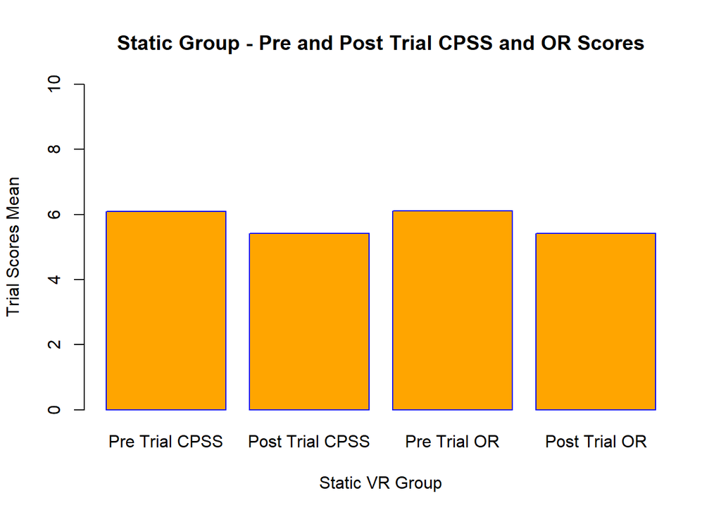

```r
static_data<-c(6.0914,5.4188,6.1032,5.4124)
CPSSOR<-c("Pre Trial CPSS","Post Trial CPSS","Pre Trial OR","Post Trial OR")
barplot(static_data,xlab="Static VR Group",ylab="Trial Scores Mean", main="Static Group - Pre and Post Trial CPSS and OR Scores", names.arg=CPSSOR, col="Orange", border="Blue", ylim=c(0,10))
```

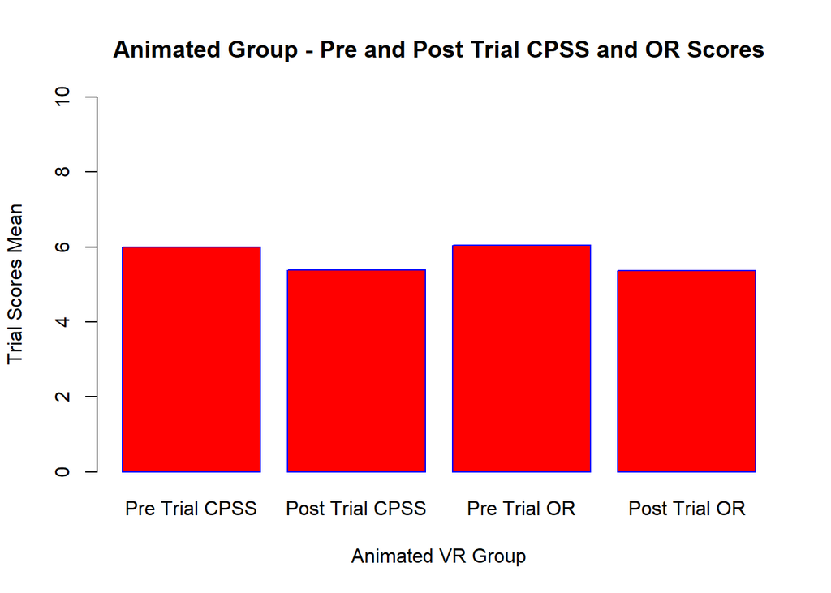

```r
animated_data<-c(5.998163265,5.387755102,6.037959184,5.364897959)
CPSSOR<-c("Pre Trial CPSS","Post Trial CPSS","Pre Trial OR","Post Trial OR")
barplot(animated_data,xlab="Animated VR Group",ylab="Trial Scores Mean", main="Animated Group - Pre and Post Trial CPSS and OR Scores", names.arg=CPSSOR, col="Red", border="Blue", ylim=c(0,10))
```

[figure not shown]

```r
control_data<-c(6.2172,5.323,6.2638,5.3314)
CPSSOR<-c("Pre Trial CPSS","Post Trial CPSS","Pre Trial OR","Post Trial OR")
barplot(control_data,xlab="Control Group",ylab="Trial Scores Mean", main="Control Group - Pre and Post Trial CPSS and OR Scores", names.arg=CPSSOR, col="Green", border="Blue", ylim=c(0,10))
```

### **Inferential Statistics**

#### *Histograms showing the normal distribution between the four Pre and Post assesments*

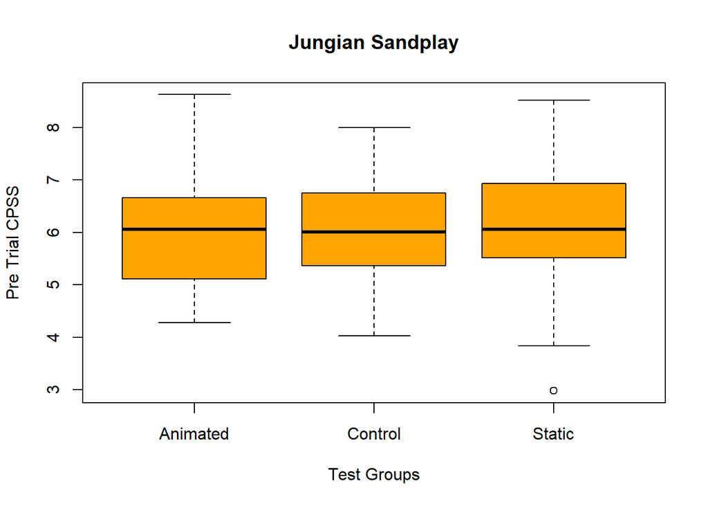

[figure not shown]

[figure not shown]

[figure not shown]

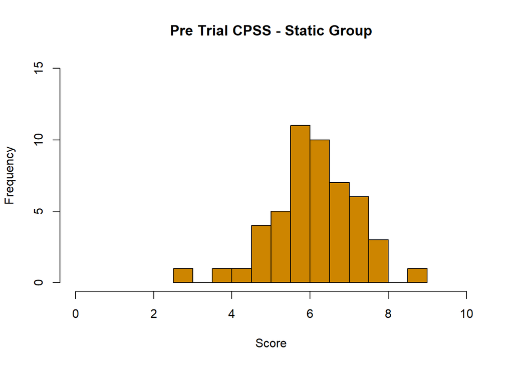

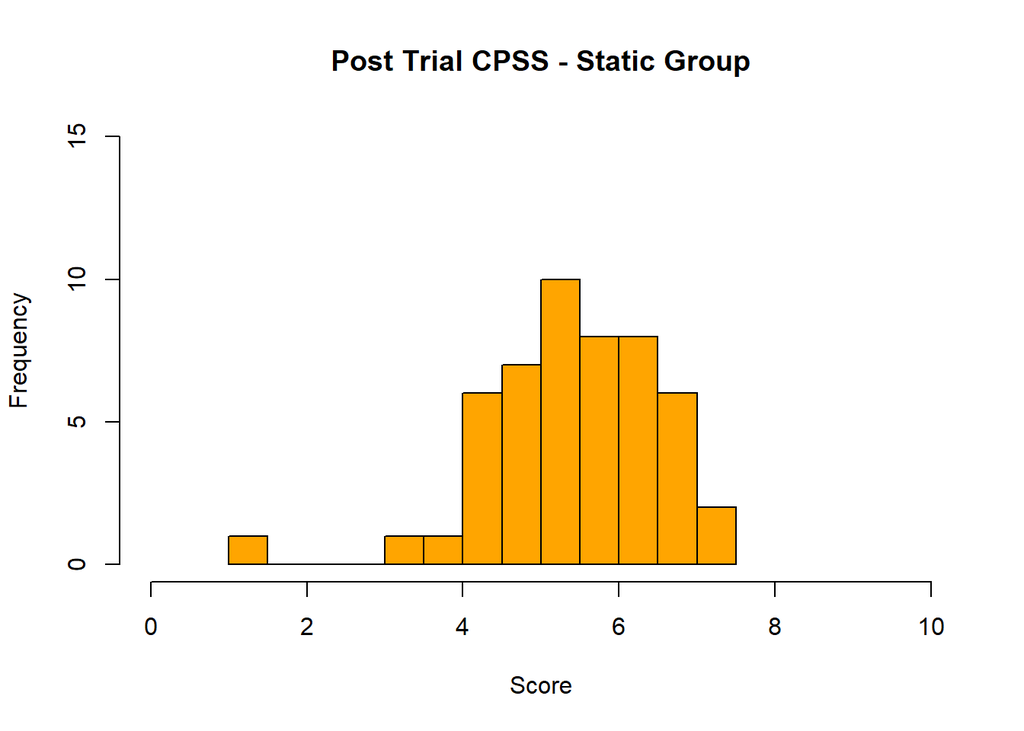

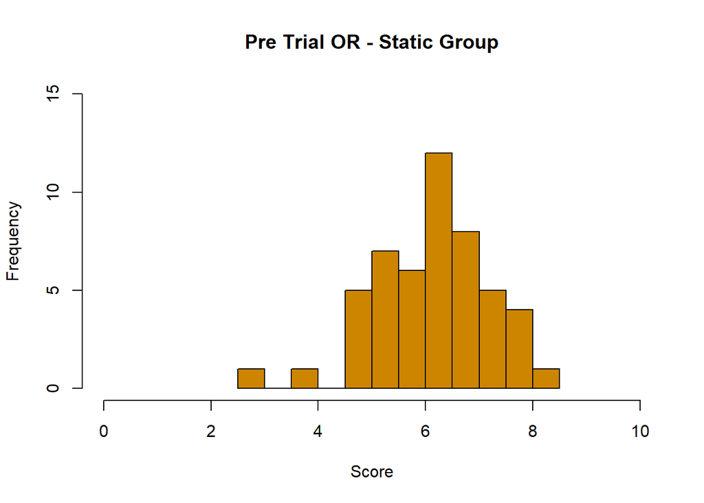

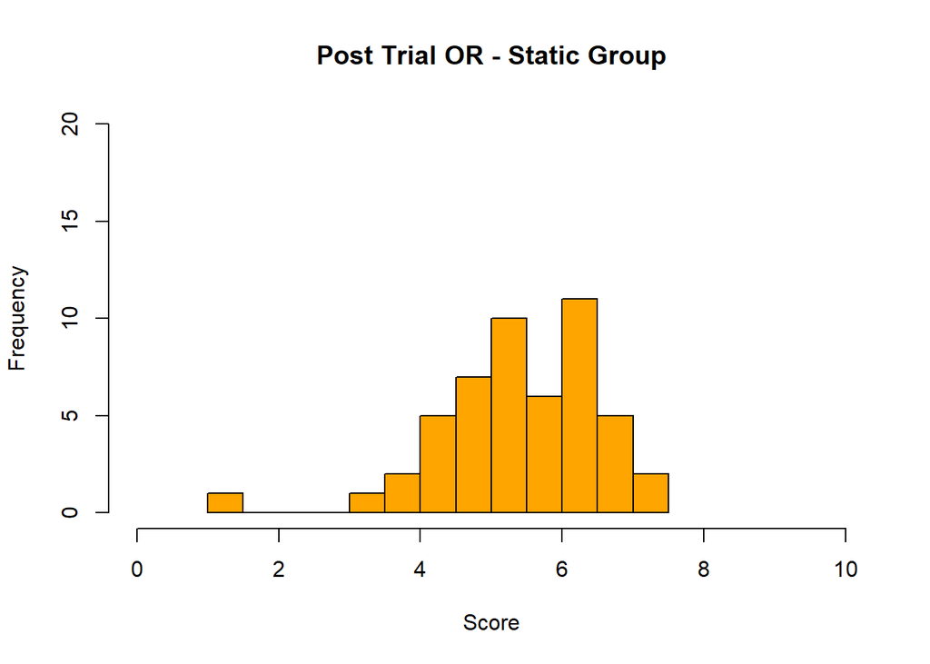

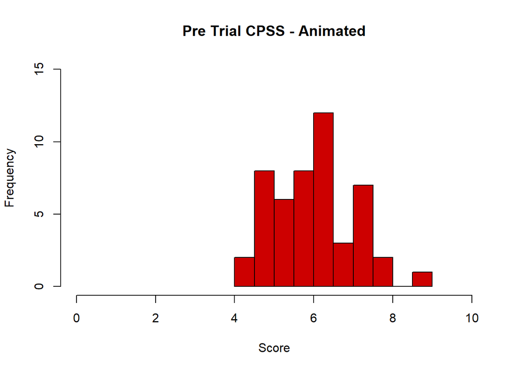

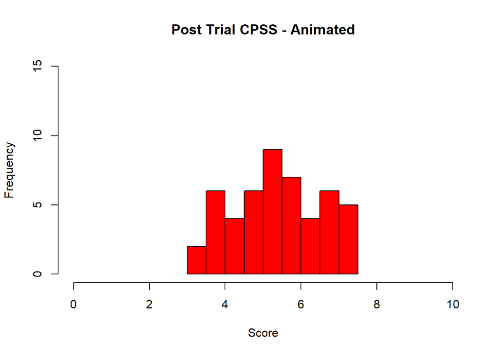

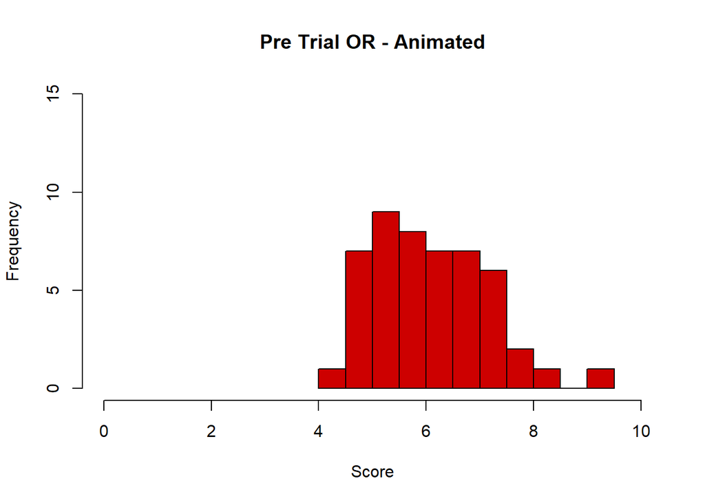

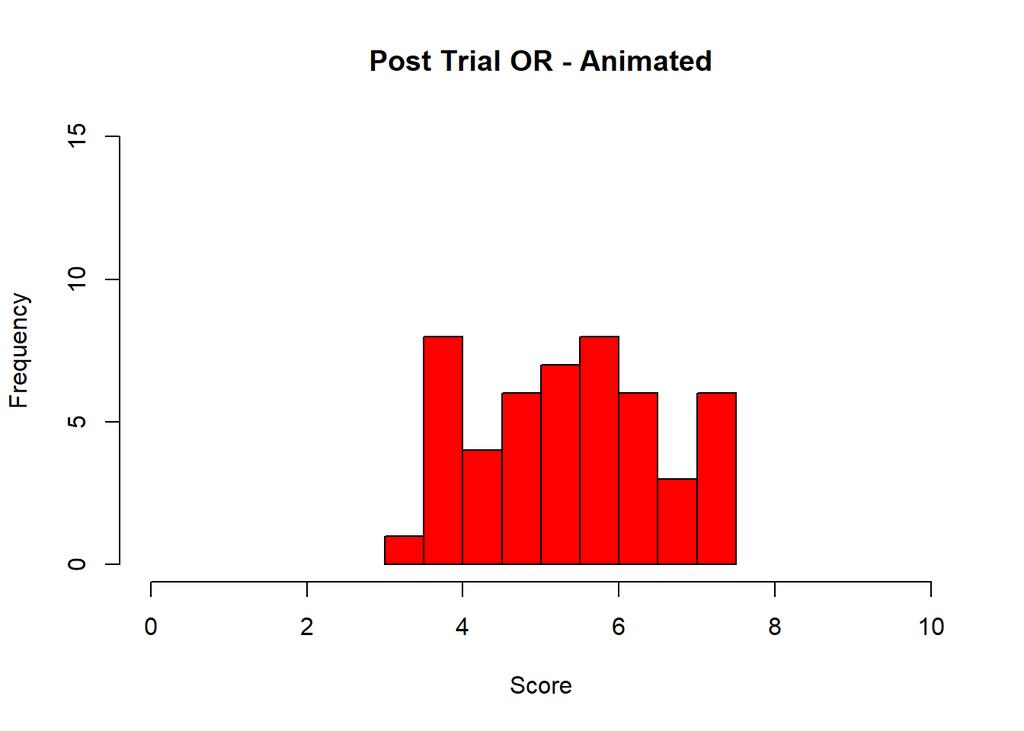

```
## # A tibble: 50 × 7
##     ...1 gender test_group pre_trial_cpss post_trial_cpss pre_trial_or post_tr…¹
##    <dbl> <chr>  <chr>               <dbl>           <dbl>        <dbl>     <dbl>
##  1    51 Male   Control              5.6             5.5          5.95      5.47
##  2    52 Male   Control              4.37            4.75         4.86      4.61
##  3    53 Male   Control              6.86            4.05         7.08      3.9
##  4    54 Male   Control              4.97            6.01         4.71      6.24
##  5    55 Male   Control              7.4             7.35         7.88      7.3
##  6    56 Male   Control              6.66            4.48         6.66      4.67
##  7    57 Male   Control              6.17            5.61         6.71      5.57
##  8    58 Male   Control              7.24            4.26         6.7       4.11
##  9    59 Male   Control              8               5.97         8.09      5.97
## 10    60 Male   Control              6.3             5.17         6.85      4.98
## # … with 40 more rows, and abbreviated variable name ¹post_trial_or
```

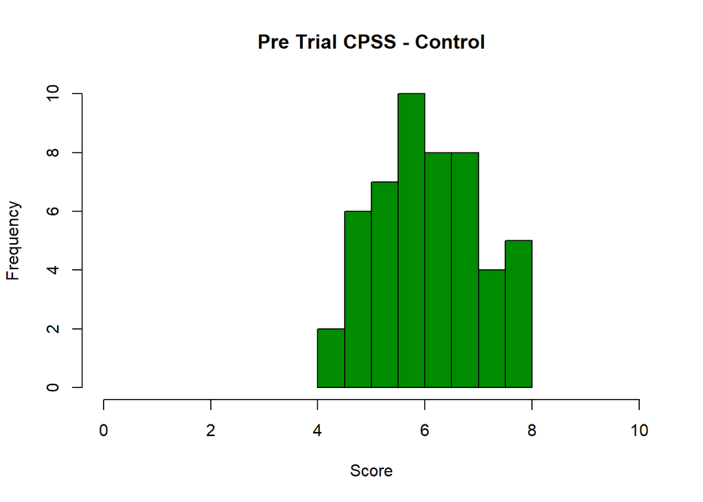

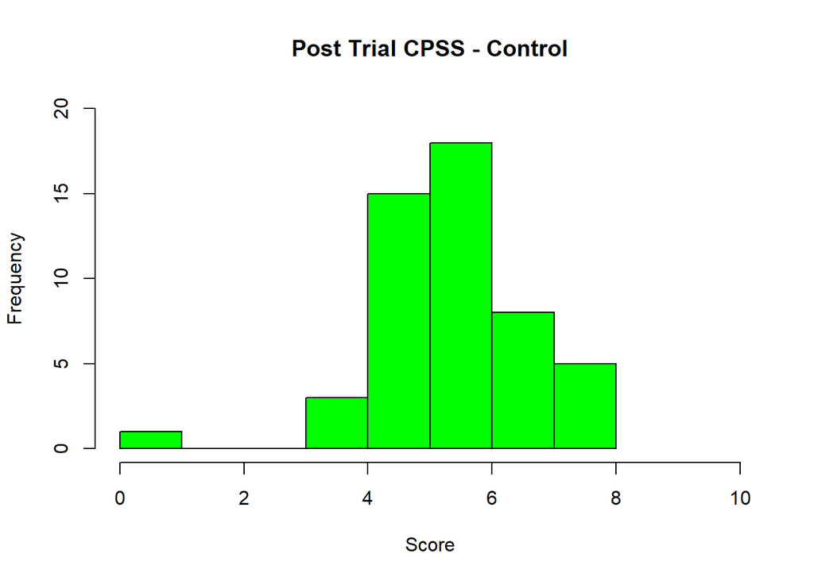

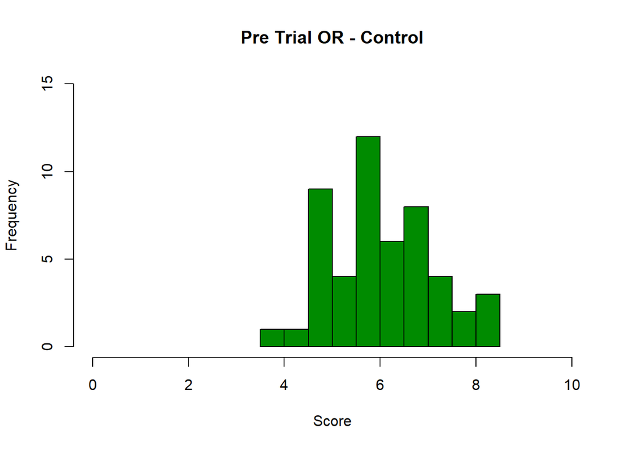

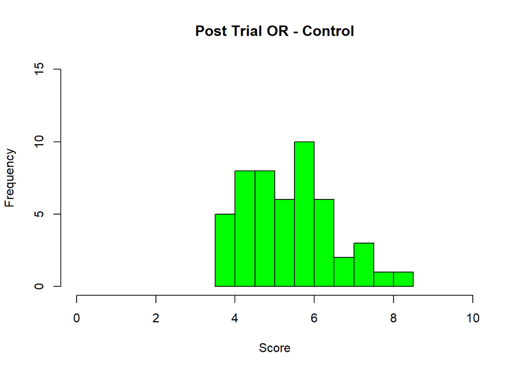

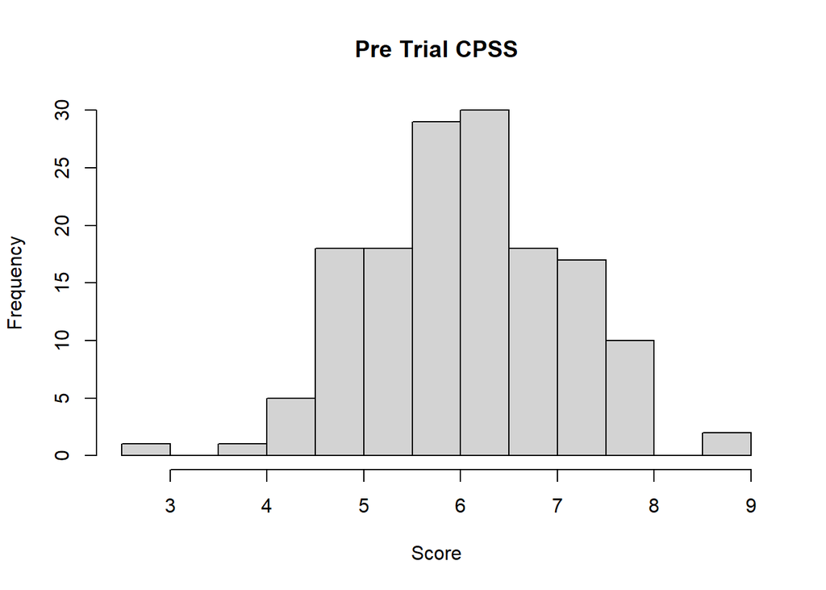

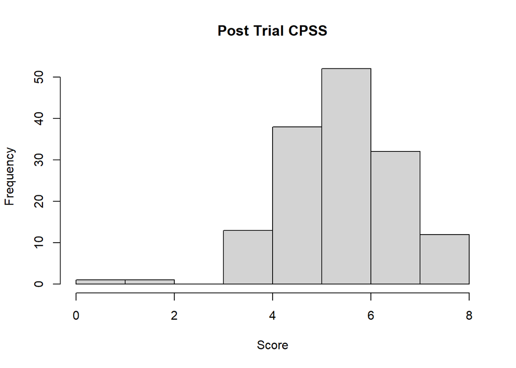

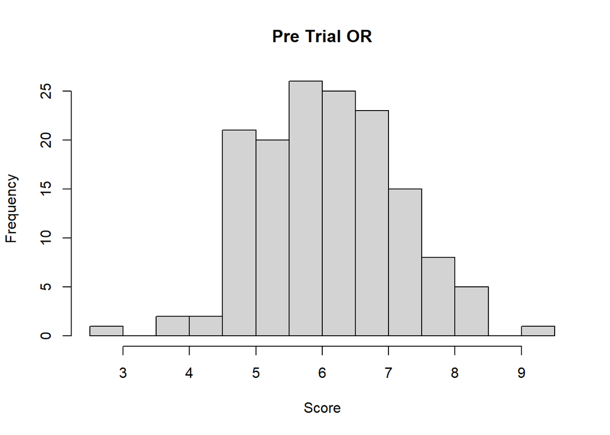

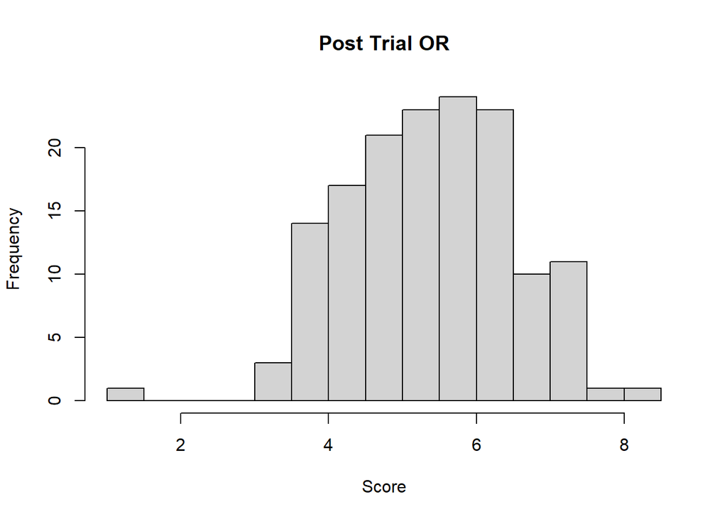

#### *QQ Plots*

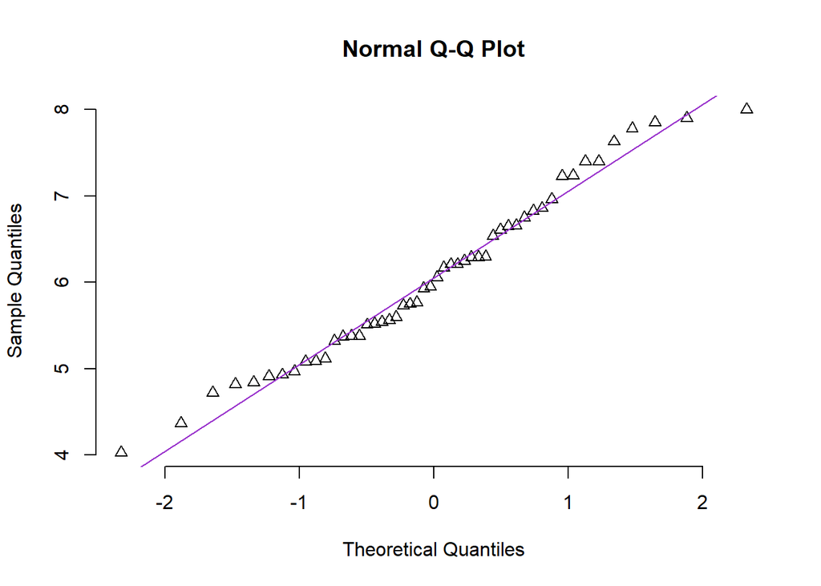

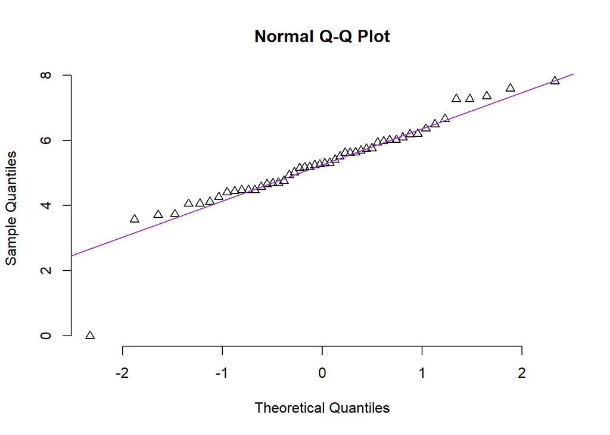

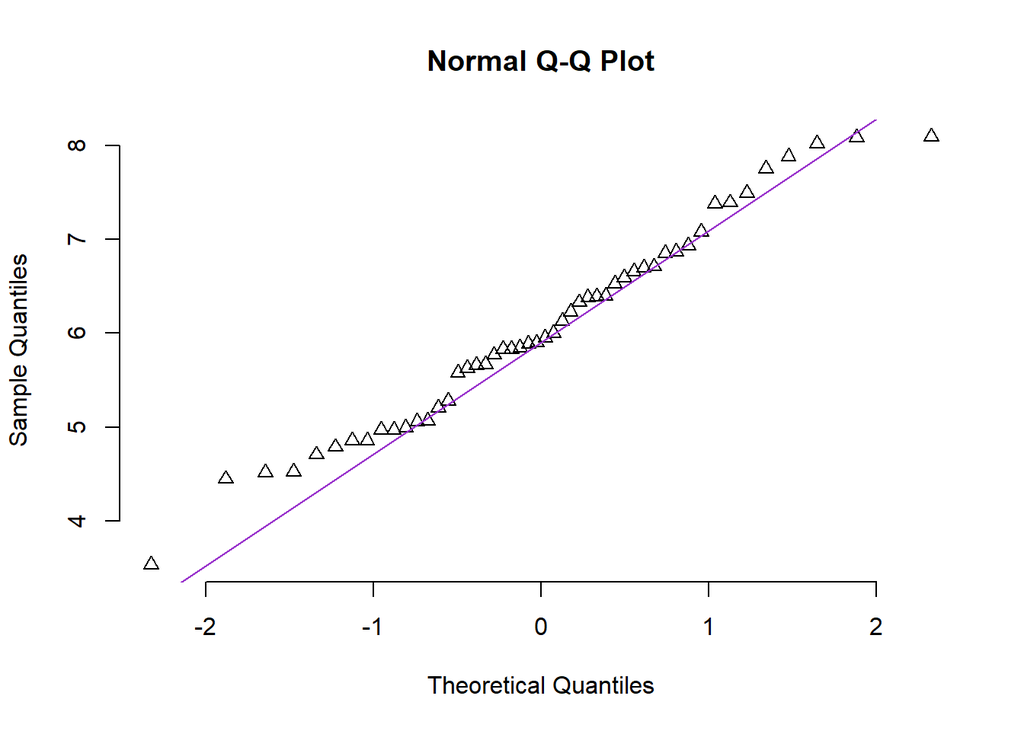

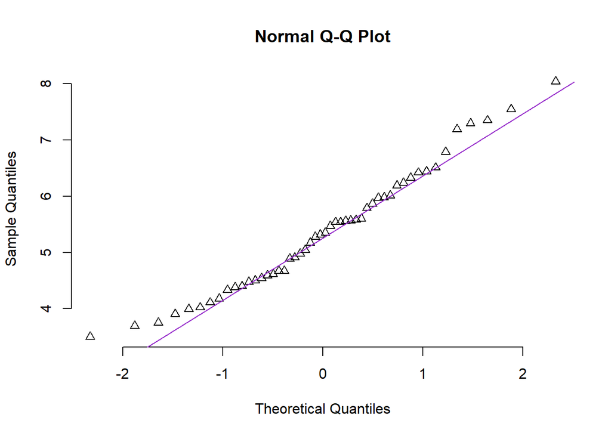

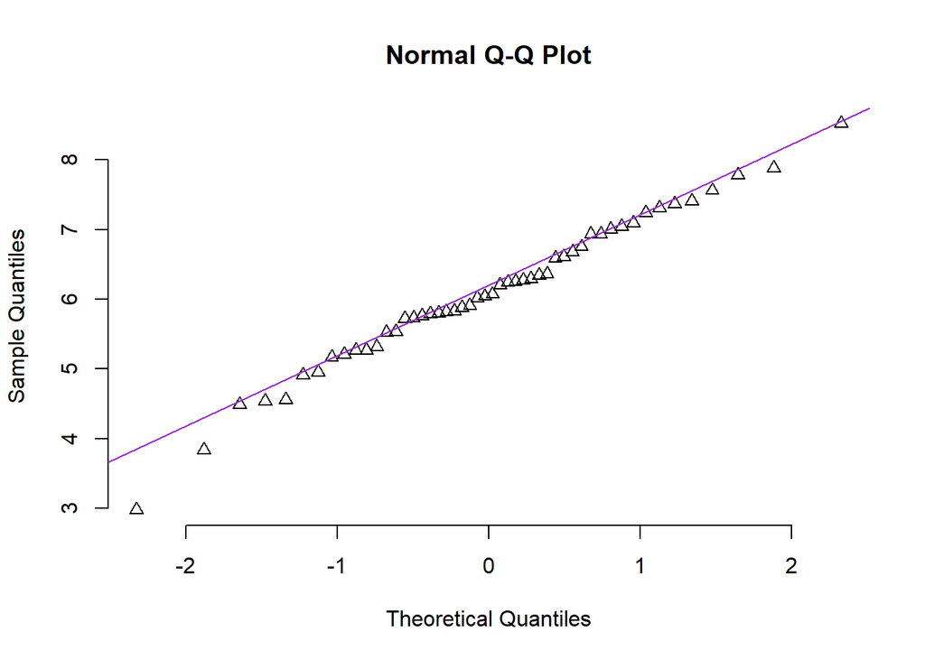

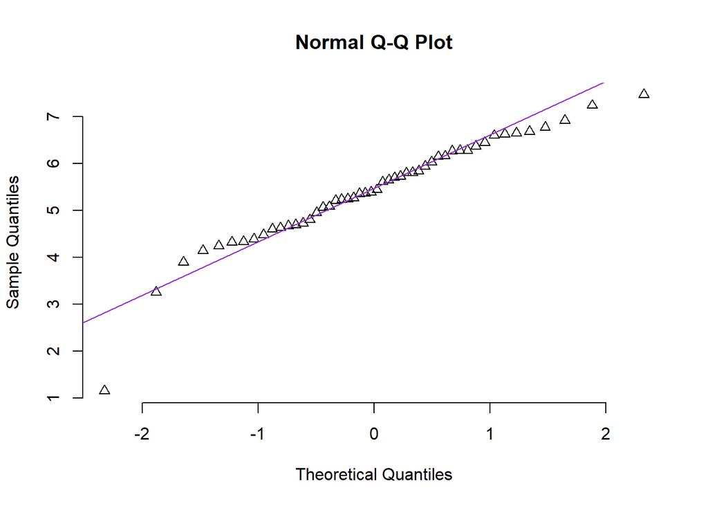

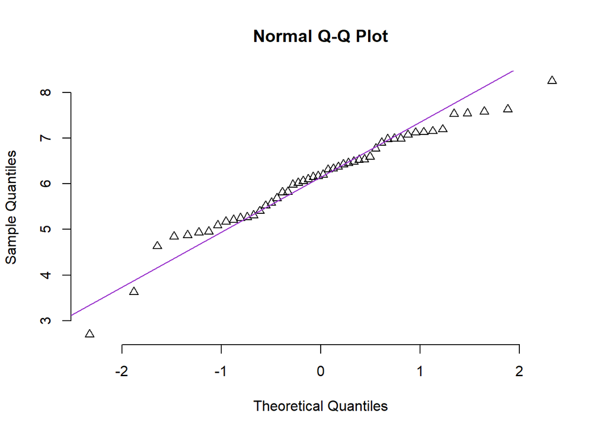

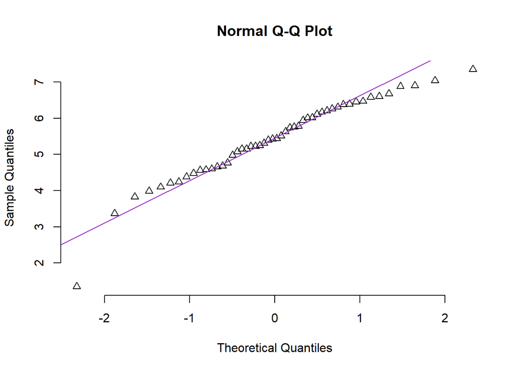

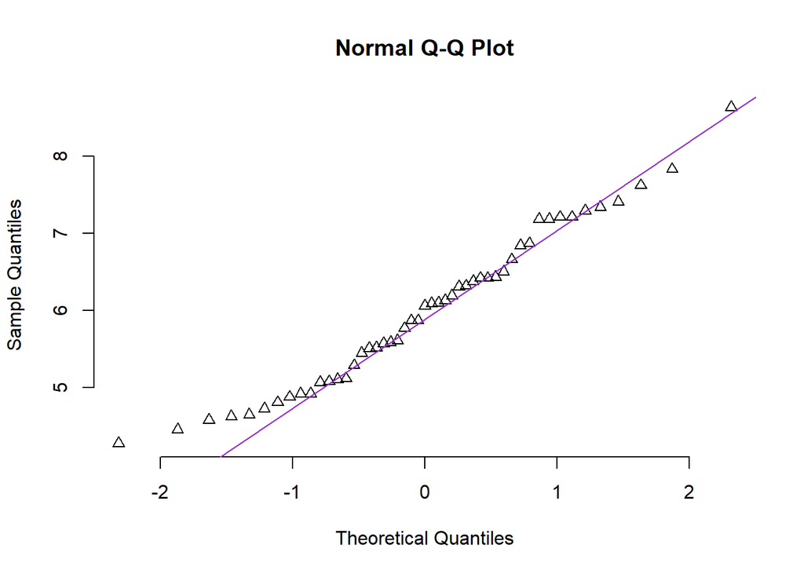

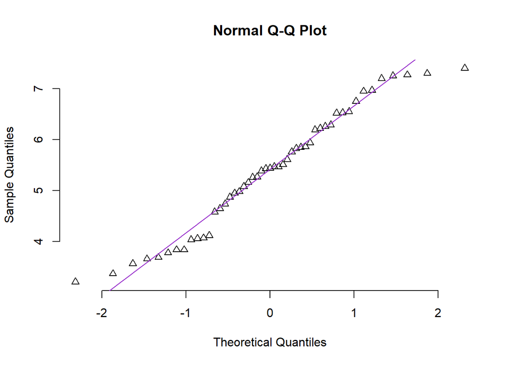

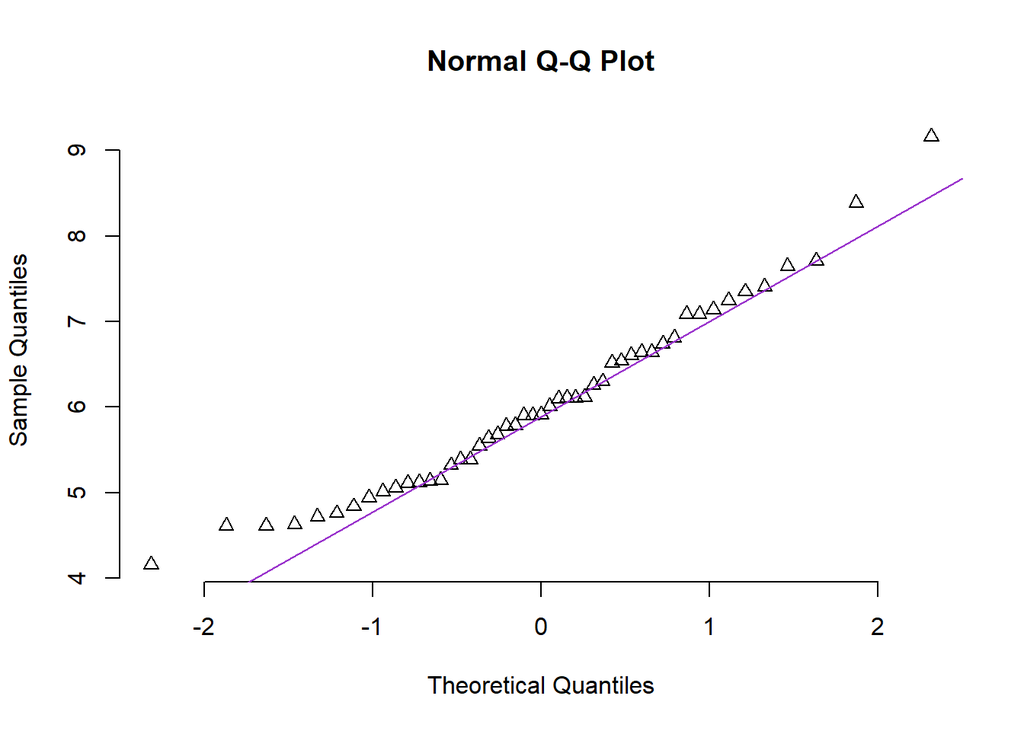

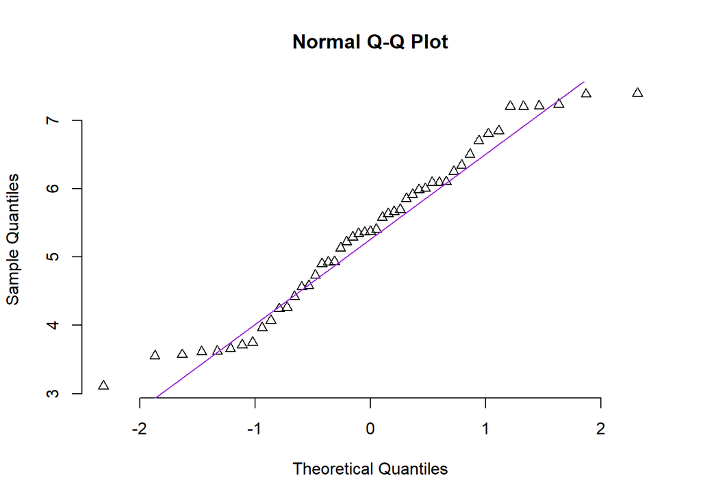

[4 more figures not shown]